# Changde Cheng

Stem Cell Biology Program, Department of Medicine  
Institute for Cancer Outcomes and Survivorship  
Department of Biomedical Informatics and Data Science  
Center for Clinical and Translational Science  
O’Neal Comprehensive Cancer Center  
Heersink School of Medicine  
University of Alabama at Birmingham

## Computational biology and cancer genomics

My current research focuses on identifying the cancer cell subpopulations responsible for relapse and understanding how microenvironments influence their response to treatment. We take high-throughput genomic analysis approaches, including single-cell RNA-seq, spatial, multiomics, and perturbation sequencing, to study cancer’s origin, progression, and therapeutic resistance. The ultimate goal is to improve cancer treatment precision, minimize disease recurrence risk, and enhance patient outcomes.

- Computational cancer biology and immunology
  - single-cell genomics
  - spatial genomics
  - multi-omics
- Theoretical biology
  - population genetics
  - quantitative genetics

## Submissions and working papers

✐

2017

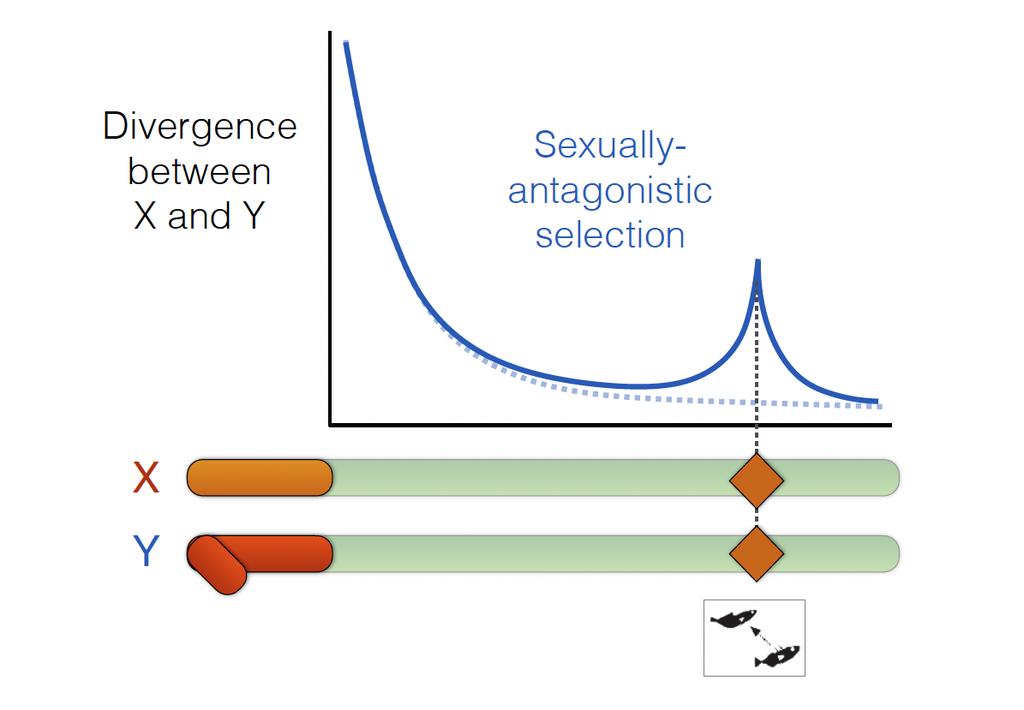

[2017-01-25] Changde Cheng, Andrius J. Dagilis, Jason M. Sardell, Asano Ishikawa, Jun Kitano, Matthew P. Josephson, Catherine L. Peichel, Mark Kirkpatrick.  
**Sexually antagonistic selection and sex chromosome evolution in Stickleback**.  
Submission to the 2017 Society for Molecular Biology & Evolution meeting at Austin, Texas, US.

✐

2023

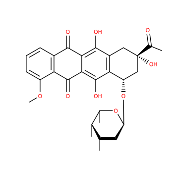

[2023-10-30] Xuexia Wang$^{\ast}$, Purnima Singh$^{\ast}$, Romina Cejas, Liting Zhou, Noha Sharafeldin, Patrick Trainor, Wendy Landier, Changde Cheng, Lindsey Hageman, Fan Wang, Yadav Sapkota, Yutaka Yasui, Melissa Hudson, Eric Chow, Saro Armenian, Joseph Neglia, Douglas Hawkins, Jill Ginsberg, Paul Burridge, Gregory Armstrong, and Smita Bhatia.  
**DNA damage response and repair genes and Anthracycline-induced cardiomyopathy in childhood cancer survivors: a report from the Children’s Oncology Group and the Childhood Cancer Survivor Study**.  
In revision.

✐

2024

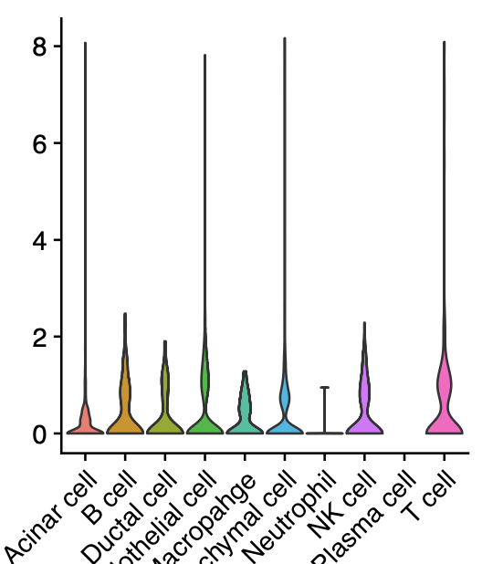

[2024-12-08] Foote JB ‡, Sarvesh S, Al Diﬀalha S, Crossman DK, Changde Cheng, Kim M, Rose BJ, Klug CA.  
**Antibody deficiency accelerates tumorigenesis in genetically engineered mouse models of pancreatic cancer.** .  
Submitted.

## Papers

🍄🍄🍄🍄

2024

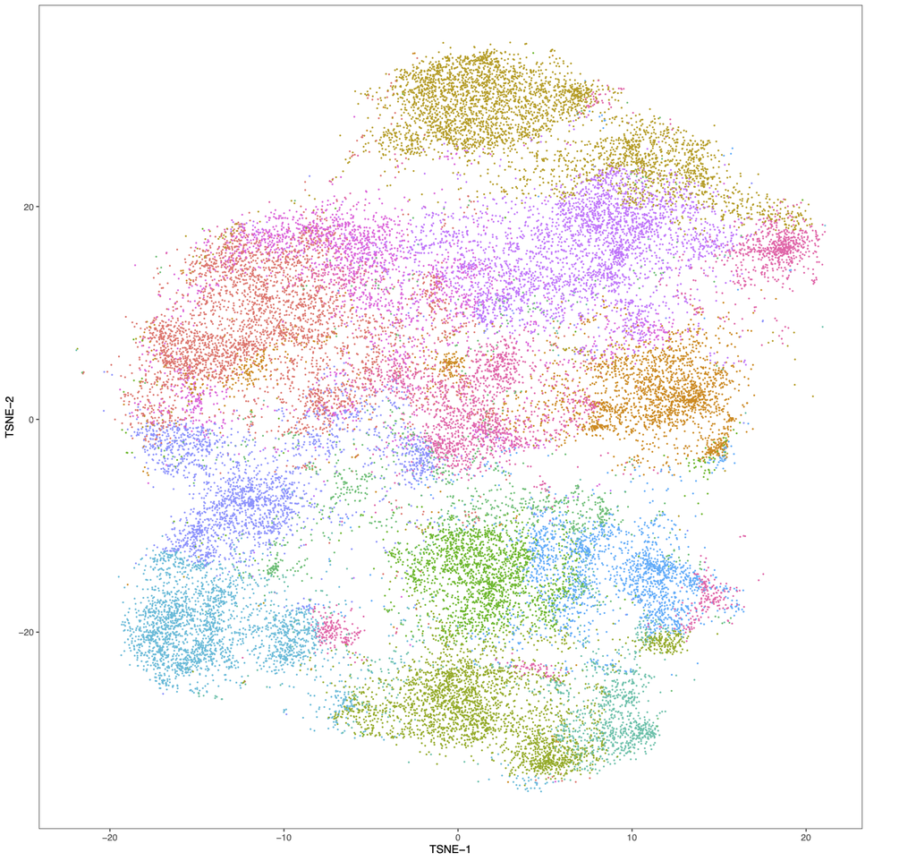

31. Tomoyoshi Tamura$^{\ast}$, Changde Cheng $^{\ast}$, Ana Villaseñor-Altamirano$^{\ast}$, Kei Hayashida, Kohei Ikeda$^{\ast}$, Kohei Yamada$^{\ast}$, Jaivardhan A Menon, Louis T. Merriam, Jack Varon, Jiyoung Choi, Aidan M. Cullen, Jingyu Guo, Benjamin A. Olenchock, Mayra A. Pinilla-Vera, Reshmi Manandhar, Muhammad Dawood Amir Sheikh, Peter C. Hou, Patrick R. Lawler, William M. Oldham, Raghu R. Seethala, Immunology of Cardiac Arrest Network (I-CAN), Rebecca M. Baron, Erin A. Bohula, David A. Morrow, Alexandra Weissman, Michael B. Brenner, Xiang Chen ‡ , Fumito Ichinose ‡ , Edy Y. Kim ‡ .  
**Innate T cells regulate early inflammation and neurological outcomes after cardiac arrest and resuscitation**  
[Science Translational Medicine](https://www.science.org/doi/10.1126/scitranslmed.adq5796) 2024 Dec 4; (16) 776.

- Best Abstract – The American Heart Association’s (AHA) Scientific Sessions 2024

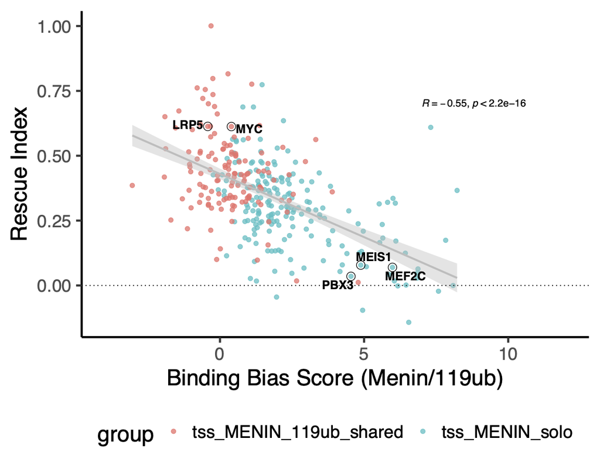

30. Xinyue Zhou, Lixia Zhang, Sajesan Aryal, Virginia Veasey, Amanda Tajik, Cecilia Restelli, Steven Moreira, Pengcheng Zhang, Yanfeng Zhang, Kristin Hope, Yang Zhou, Changde Cheng, Ravi Bhatia, and Rui Lu.  
**Epigenetic regulation of non-canonical menin targets modulates menin inhibitor response in acute myeloid leukemia**  
[Blood](https://doi.org/10.1182/blood.2023023644) 2024 Nov 7; 144 (19): 2018–2032.

- [Broken brakes: PRC loss foils menin inhibition](https://doi.org/10.1182/blood.2024026297) – Commentary in Blood

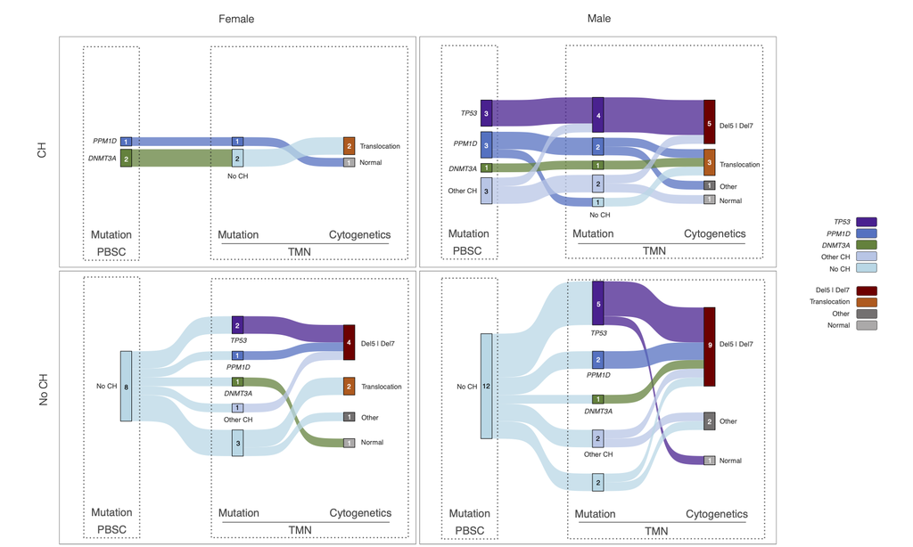

29. Melissa A Richard$^{\ast}$, Chengcheng Yan$^{\ast}$, Yanjun Chen, Christopher J Gibson, Rashi Kalra, Alysia Bosworth, David K Crossman, Purnima Singh, Lindsey Hageman, Jianbo He, Saro H Armenian, Julie Vose, Daniel J Weisdorf, Benjamin L Ebert, Yutaka Yasui, Changde Cheng, Stephen J Forman , Smita Bhatia$^{\dagger}$, Ravi Bhatia$^{\dagger}$  
**Sex-based differences in risk for therapy-related myeloid neoplasms**  
[Journal of Clinical Oncology](https://doi.org/10.1200/JCO-24-01487) 2024 Nov 1; Vol. 42, No 31.

- [Battle of the sexes in the clonal world](https://doi.org/10.1200/JCO-24-01758) – Editorials in JCO

28. Yamada K$^{\dagger}$, Menon JA, Kim Y, Changde Cheng, Chen W, Shih JA, Villasenor-Altamirano AB, Chen X, Immunology of Cardiac Arrest Network (I-CAN), Tamura T, Merriam LT, Kim EY$^{\dagger}$, Weissman AJ$^{\dagger}$.  
**Protocol for immunophenotyping out-of-hospital cardiac arrest patients**  
[STAR Protocols](https://www.sciencedirect.com/science/article/pii/S266616672400039X) 2024 Mar 15; 5 (1), 102874.

🍄🍄🍄🍄

2023

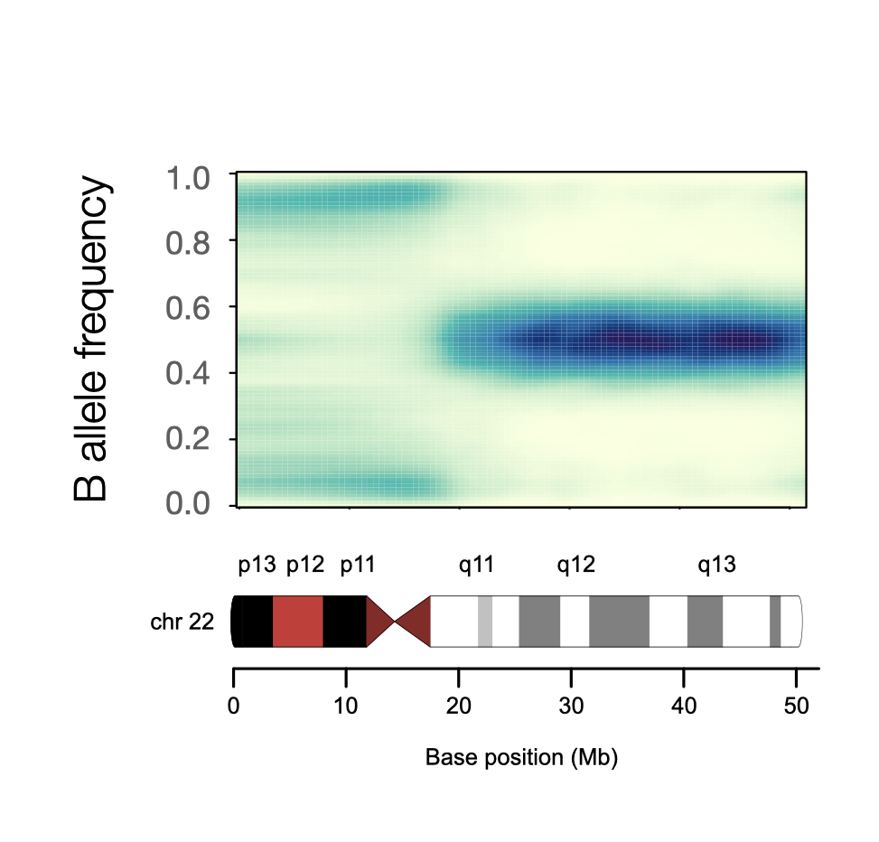

27. Murphy AJ$^{\ast \dagger}$, Changde Cheng $^{\ast}$, Williams J, Shaw TI, Pinto EM, Dieseldorff-Jones K, Brzezinski J, Renfro LA, Tornwall B, Huff V, Hong AL, Mullen EA, Crompton B, Dome JS, Fernandez CV, Geller JI, Ehrlich PF, Mulder H, Oak N, Maciezsek J, Jablonowski C, Fleming AM, Pichavaram P, Morton CL, Easton J, Nichols KE, Clay MR, Santiago T, Zhang J, Yang J, Zambetti GP, Wang Z, Davidoff AM, Chen X $^{\dagger}$.  
**Genetic and epigenetic features of bilateral Wilms tumor predisposition in patients from the Children’s Oncology Group AREN18B5-Q**  
[Nat Commun.](https://www.nature.com/articles/s41467-023-43730-0) 2023 Dec 18; 14, 8006.

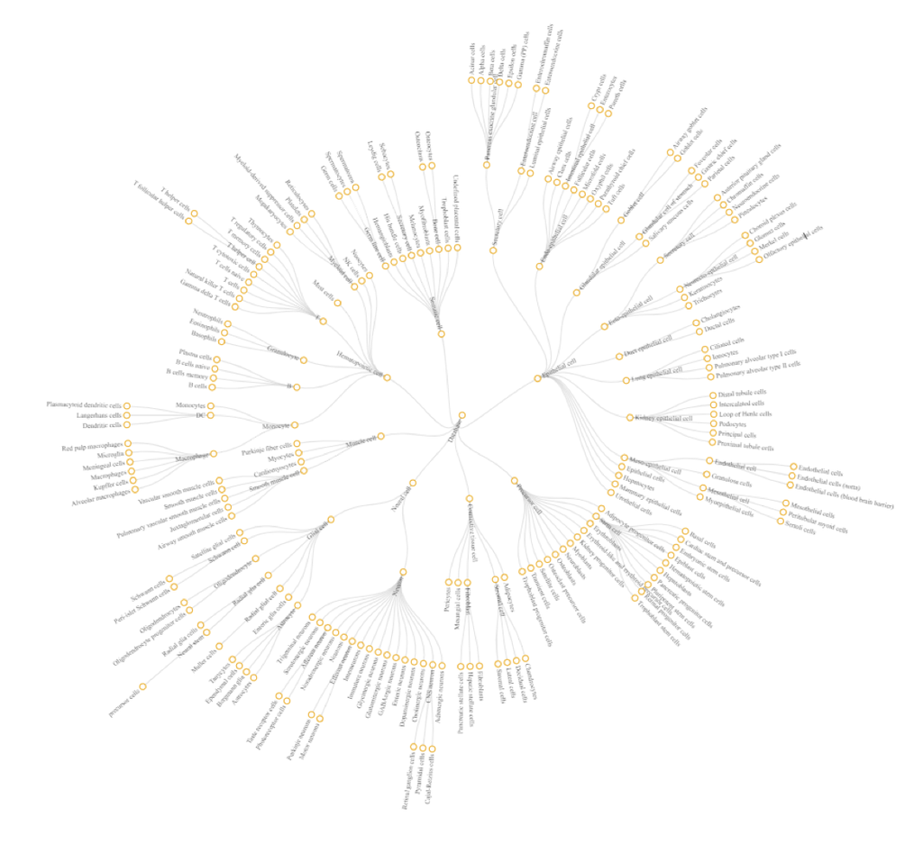

26. Changde Cheng $^{\ast}$, Chen W$^{\ast}$, Jin H$^{\ast}$, Chen X.  
**A review of single-cell rna-seq annotation, integration, and cell-cell communication**  
[Cells.](https://pubmed.ncbi.nlm.nih.gov/37566049/) 2023 Jul 30;12(15). Review.

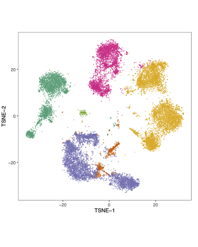

25. Tamura T$^{\ast}$, Changde Cheng $^{\ast}$, Chen W, Merriam LT, Athar H, Kim YH, Manandhar R, Amir Sheikh MD, Pinilla-Vera M, Varon J, Hou PC, Lawler PR, Oldham WM, Seethala RR, Tesfaigzi Y, Weissman AJ, Baron RM, Ichinose F, Berg KM, Bohula EA, Morrow DA, Chen X, Kim EY.  
**Single-cell transcriptomics reveal a hyperacute cytokine and immune checkpoint axis after cardiac arrest in patients with poor neurological outcome**  
[Med.](https://www.ncbi.nlm.nih.gov/pubmed/37257452/) 2023 Jul 14;4(7):432-456.e6.

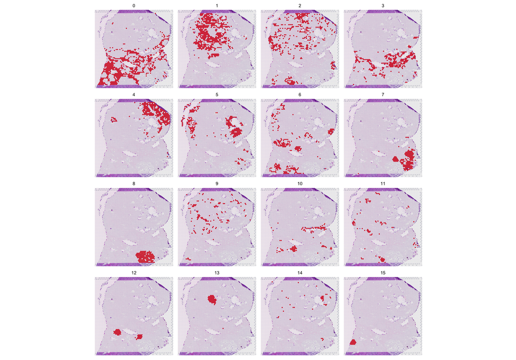

24. Fang J$^{\ast}$, Singh S$^{\ast}$, Changde Cheng $^{\ast}$, Natarajan S$^{\ast}$, Sheppard H$^{\ast}$, Abu-Zaid A, Durbin AD, Lee HW, Wu Q, Steele J, Connelly JP, Jin H, Chen W, Fan Y, Pruett-Miller SM, Rehg JE, Koo SC, Santiago T, Emmons J, Cairo S, Wang R, Glazer ES, Murphy AJ, Chen T, Davidoff AM, Armengol C, Easton J, Chen X, Yang J.  
**Genome-wide mapping of cancer dependency genes and genetic modifiers of chemotherapy in high-risk hepatoblastoma**  
[Nat Commun.](https://www.ncbi.nlm.nih.gov/pubmed/37414763/) 2023 Jul 6;14(1):4003.

- [Spatial omics takes oﬀ](https://www.stjude.org/research/progress/2023/spatial-omics-takes-off.html) – St. Jude Progress  
  Our work serves as a key example of leveraging spatial transcriptomics to uncover the heterogeneity of hepatoblastoma tumors and to illuminate their responses to different therapeutic interventions.

🍄

2022

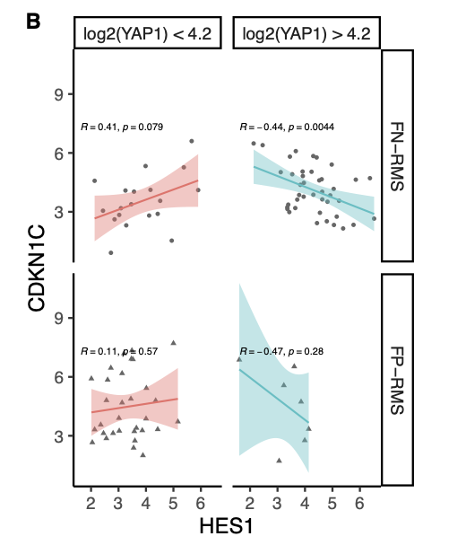

23. Kovach AR, Oristian KM, Kirsch DG, Bentley RC, Changde Cheng, Chen X, Chen PH, Chi JA, Linardic CM.  
**Identification and targeting of a HES1-YAP1-CDKN1C functional interaction in fusion-negative rhabdomyosarcoma**  
[Mol Oncol.](https://www.ncbi.nlm.nih.gov/pubmed/36037042/) 2022 Oct;16(20):3587-3605.

🍄🍄

2021

[figure not shown]

22. Changde Cheng, Kirkpatrick M.  
**Molecular evolution and the decline of purifying selection with age**  
[Nat Commun.](https://www.ncbi.nlm.nih.gov/pubmed/33976227/) 2021 May 11;12(1):2657.

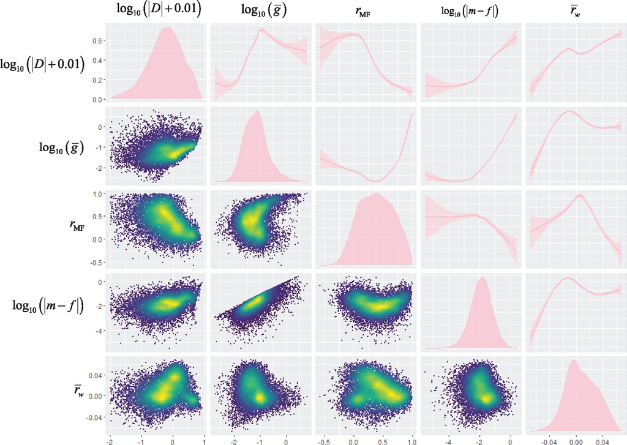

21. Houle D, Changde Cheng.  
**Predicting the evolution of sexual dimorphism in gene expression**  
[Mol Biol Evol.](https://www.ncbi.nlm.nih.gov/pubmed/33512493/) 2021 May 4;38(5):1847-1859.

🍄

2020

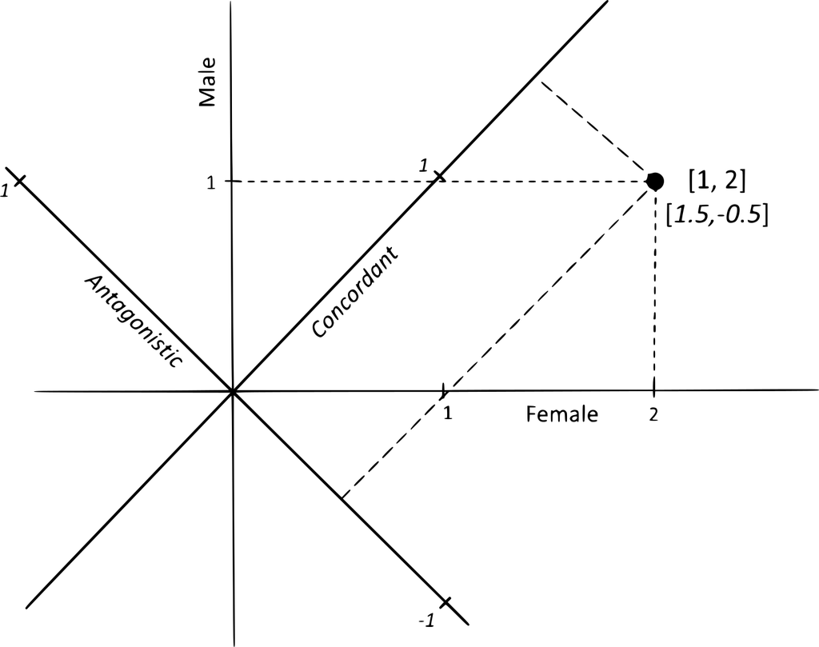

20. Changde Cheng, Houle D.  
**Predicting multivariate responses of sexual dimorphism to direct and indirect selection**  
[Am Nat.](https://www.ncbi.nlm.nih.gov/pubmed/32970462/) 2020 Oct;196(4):391-405.

🍄🍄🍄

2019

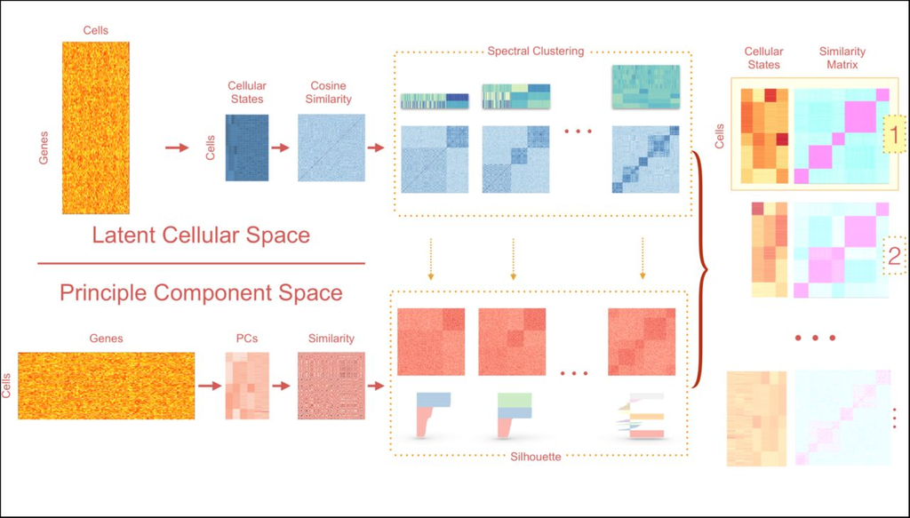

19. Changde Cheng, Easton J, Rosencrance C, Li Y, Ju B, Williams J, Mulder HL, Pang Y, Chen W, Chen X.  
**Latent cellular analysis robustly reveals subtle diversity in large-scale single-cell RNA-seq data**  
[Nucleic Acids Res.](https://www.ncbi.nlm.nih.gov/pubmed/31566233/) 2019 Dec 16;47(22):e143.

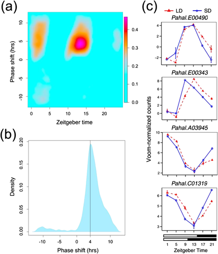

18. Weng X, Lovell JT, Schwartz SL, Changde Cheng, Haque T, Zhang L, Razzaque S, Juenger TE.  
**Complex interactions between day length and diurnal patterns of gene expression drive photoperiodic responses in a perennial C(4) grass**  
[Plant Cell Environ.](https://www.ncbi.nlm.nih.gov/pubmed/30847928/) 2019 Jul;42(7):2165-2182.

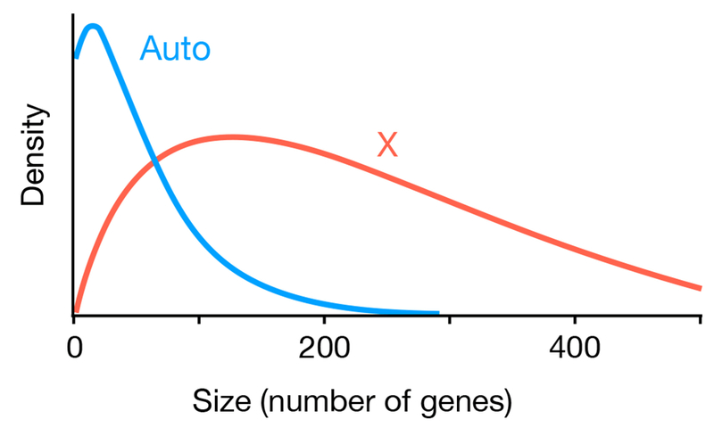

17. Changde Cheng, Kirkpatrick M.  
**Inversions are bigger on the X chromosome**  
[Mol Ecol.](https://www.ncbi.nlm.nih.gov/pubmed/30059177/) 2019 Mar;28(6):1238-1245.

🍄🍄🍄

2018

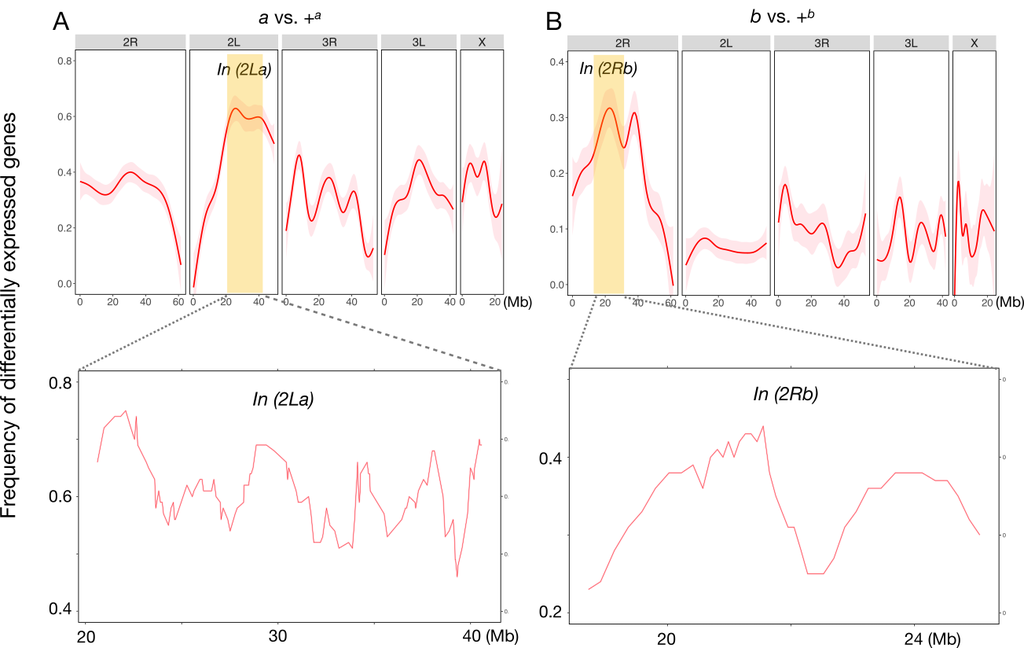

16. Changde Cheng, Tan JC, Hahn MW, Besansky NJ.  
**Systems genetic analysis of inversion polymorphisms in the malaria mosquito Anopheles gambiae**  
[Proc Natl Acad Sci U S A.](https://www.ncbi.nlm.nih.gov/pubmed/29987007/) 2018 Jul 24;115(30):E7005-E7014.

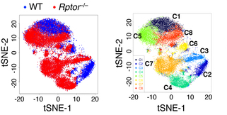

15. Yang K, Blanco DB, Chen X, Dash P, Neale G, Rosencrance C, Easton J, Chen W, Changde Cheng, Dhungana Y, Kc A, Awad W, Guo XJ, Thomas PG, Chi H.  
**Metabolic signaling directs the reciprocal lineage decisions of αβ and γδ T cells**  
[Sci Immunol.](https://www.ncbi.nlm.nih.gov/pubmed/29980617/) 2018 Jul 6;3(25).

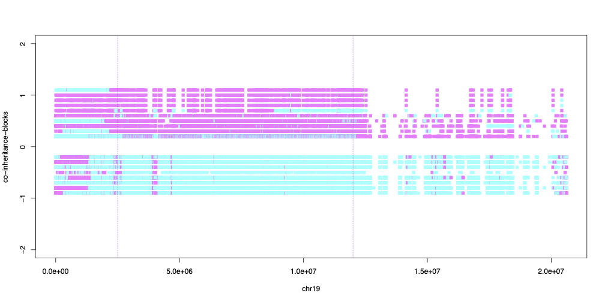

14. Sardell JM, Changde Cheng, Dagilis AJ, Ishikawa A, Kitano J, Peichel CL, Kirkpatrick M.  
**Sex differences in recombination in sticklebacks**  
[G3 (Bethesda)](https://www.ncbi.nlm.nih.gov/pubmed/29632132/) . 2018 May 31;8(6):1971-1983.

🍄🍄

2017

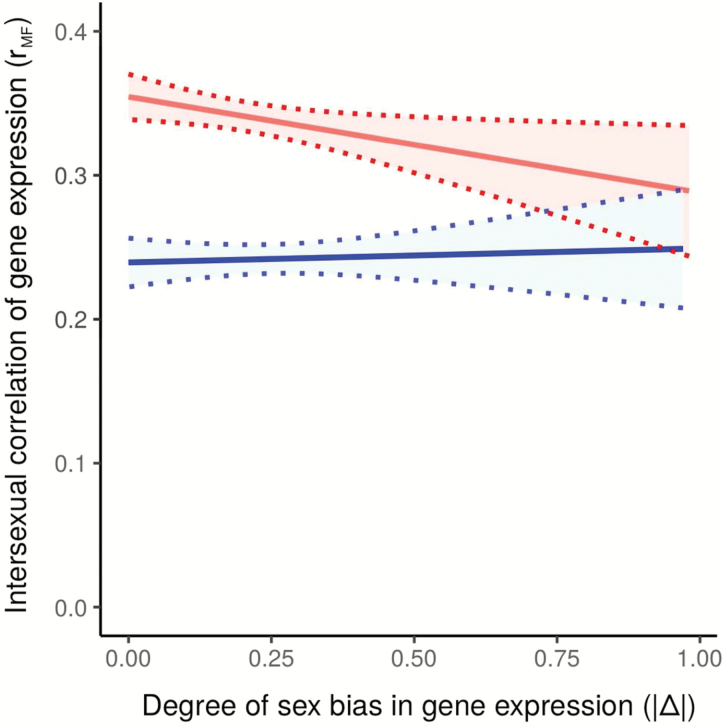

13. Changde Cheng, Kirkpatrick M.  
**Environmental plasticity in the intersexual correlation and sex bias of gene xxpression**  
[J Hered.](https://www.ncbi.nlm.nih.gov/pubmed/29036352/) 2017 Oct 30;108(7):754-758.

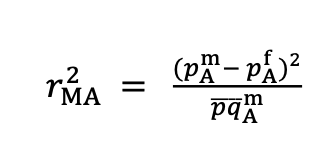

12. Fontaine A, Filipovic I, Fansiri T, Hoffmann AA, Changde Cheng, Kirkpatrick M, Rašic G, Lambrechts L.  
**Extensive genetic differentiation between homomorphic sex chromosomes in the sosquito vector, Aedes aegypti**  
[Genome Biol Evol.](https://www.ncbi.nlm.nih.gov/pubmed/28945882/) 2017 Sep 1;9(9):2322-2335.

🍄🍄🍄

2016

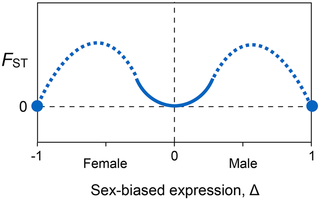

11. Changde Cheng, Kirkpatrick M.  
**Sex-Specific selection and sex-biased gene expression in humans and flies**  
[PLoS Genet.](https://www.ncbi.nlm.nih.gov/pubmed/27658217/) 2016 Sep;12(9):e1006170.

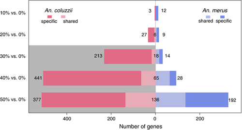

10. Uyhelji HA, Changde Cheng, Besansky NJ.  
**Transcriptomic differences between euryhaline and stenohaline malaria vector sibling species in response to salinity stress**  
[Mol Ecol.](https://www.ncbi.nlm.nih.gov/pubmed/26945667/) 2016 May;25(10):2210-25.

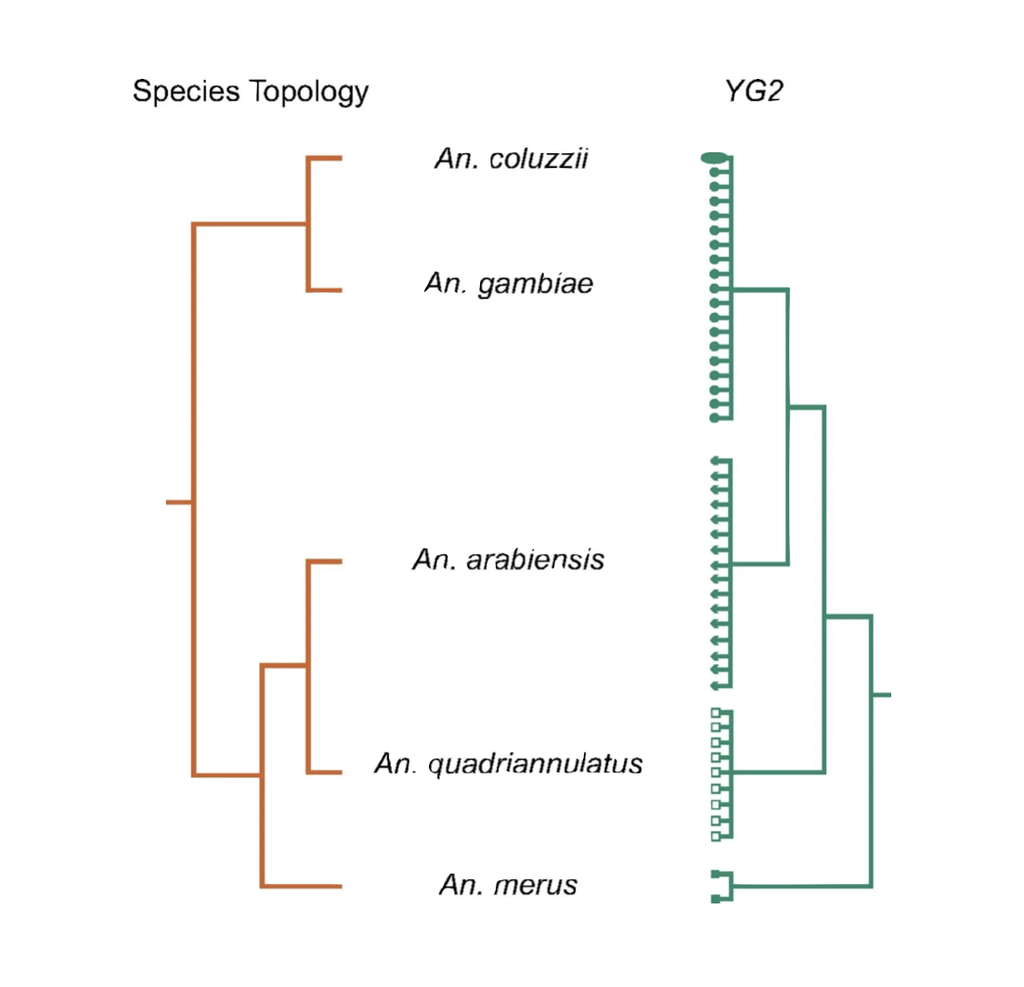

9. Hall AB$^{\ast}$, Papathanos PA$^{\ast}$, Sharma A$^{\ast}$, Changde Cheng $^{\ast}$, Akbari OS, Assour L, Bergman NH, Cagnetti A, Crisanti A, Dottorini T, Fiorentini E, Galizi R, Hnath J, Jiang X, Koren S, Nolan T, Radune D, Sharakhova MV, Steele A, Timoshevskiy VA, Windbichler N, Zhang S, Hahn MW, Phillippy AM, Emrich SJ, Sharakhov IV, Tu ZJ, Besansky NJ.  
**Radical remodeling of the Y chromosome in a recent radiation of malaria mosquitoes**  
[Proc Natl Acad Sci U S A.](https://www.ncbi.nlm.nih.gov/pubmed/27035980/) 2016 Apr 12;113(15):E2114-23.

🍄

2015

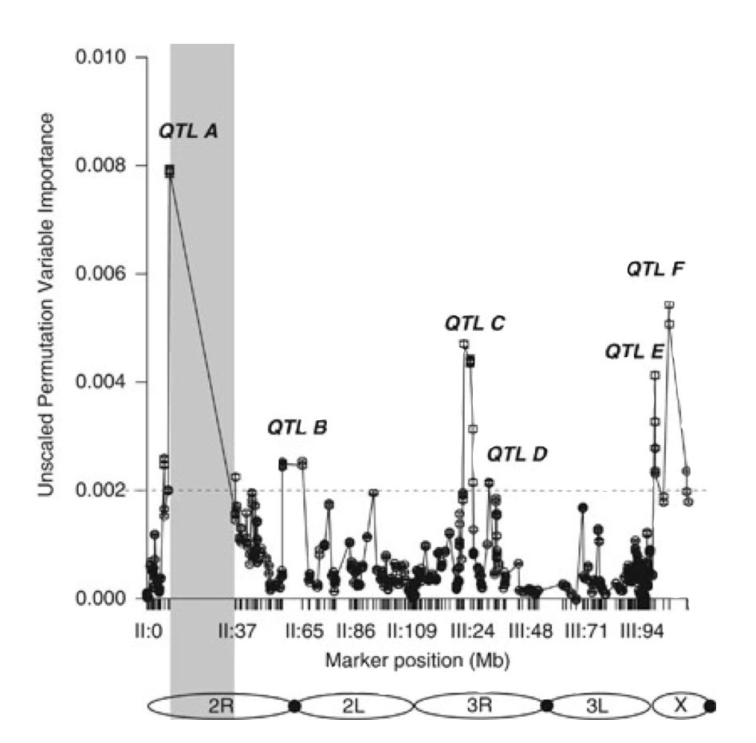

8. Smith HA, White BJ, Kundert P, Changde Cheng, Romero-Severson J, Andolfatto P, Besansky NJ.  
**Genome-wide QTL mapping of saltwater tolerance in sibling species of Anopheles (malaria vector) mosquitoes**  
[Heredity (Edinb).](https://www.ncbi.nlm.nih.gov/pubmed/25920668/) 2015 Nov;115(5):471-9.

🍄🍄

2014

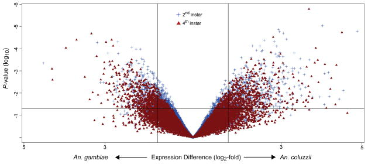

7. Cassone BJ, Kamdem C, Changde Cheng, Tan JC, Hahn MW, Costantini C, Besansky NJ.  
**Gene expression divergence between malaria vector sibling species Anopheles gambiae and An. coluzzii from rural and urban Yaoundé Cameroon**  
[Mol Ecol.](https://www.ncbi.nlm.nih.gov/pubmed/24673723/) 2014 May;23(9):2242-59.

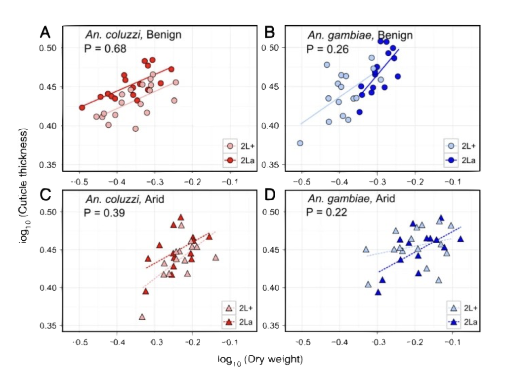

6. Reidenbach KR, Changde Cheng, Liu F, Liu C, Besansky NJ, Syed Z.  
**Cuticular differences associated with aridity acclimation in African malaria vectors carrying alternative arrangements of inversion 2La**  
[Parasit Vectors.](https://www.ncbi.nlm.nih.gov/pubmed/24721548/) 2014 Apr 10;7:176.

🍄